# Andamento dei prezzi dei laptop

### Obiettivo:

Capire se c'è una relazione tra il prezzo e altre caratteristiche di un laptop.

### Domande:

1. Quale fascia di laptop è prodotta in maggiore quantità ? Cambia a seconda della famiglia del processore ?
2. Qual è il peso medio dei laptop in base alla marca? C'è una relazione tra il prezzo e il peso del laptop ?
3. Il prezzo varia regolarmente in base alla risoluzione schermo?
4. Negli anni il divario di prezzo tra gli schermi 4K e FHD è diminuito?

## Dati utilizzati

**Dataset:**

[Laptop Price Dataset](https://www.kaggle.com/datasets/asinow/laptop-price-dataset)

**Dati utilizzati:**

Brand, Processore, GPU e altre caratteristiche tecniche.

**Crediti del dataset:**

[Asinow](https://www.kaggle.com/asinow)

# Quale fascia di laptop è prodotta in maggiore quantità ?

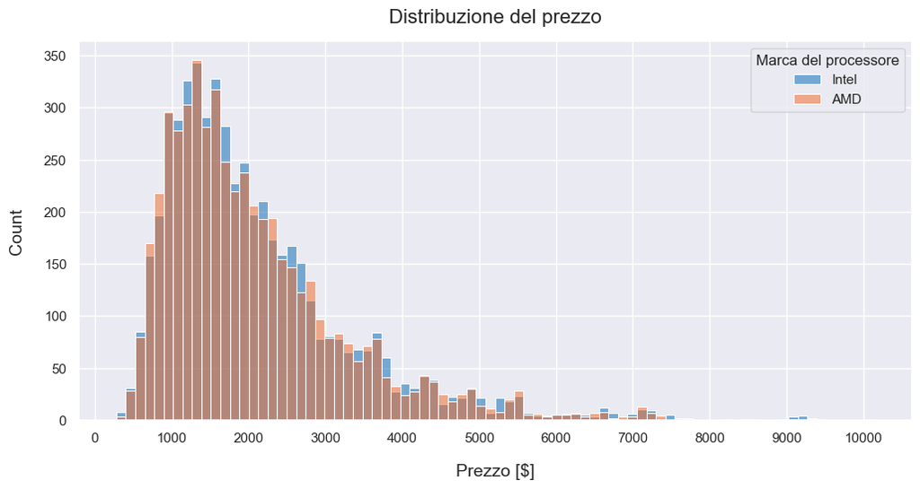

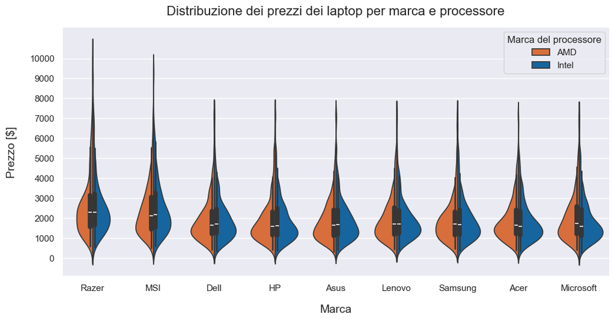

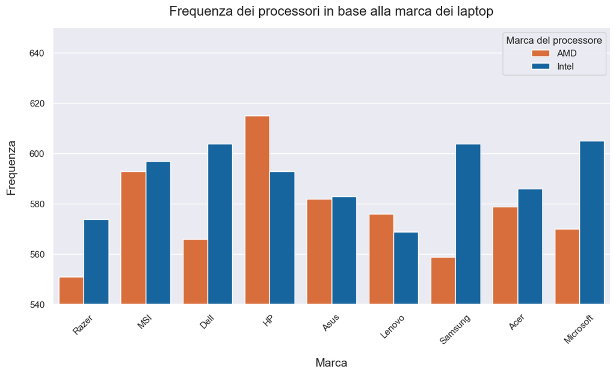

# Qual è il peso medio dei laptop in base alla marca?

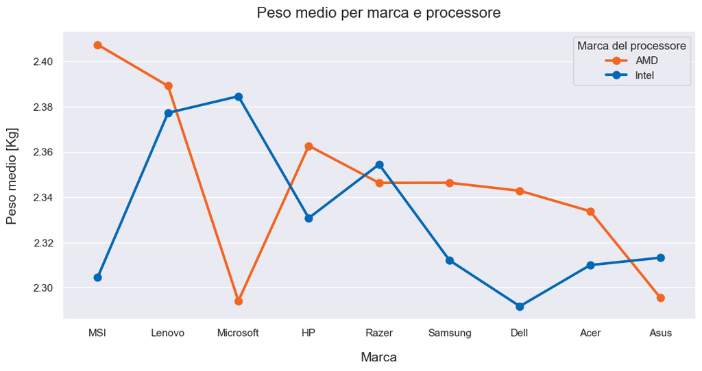

# C'è una relazione tra il prezzo e il peso del laptop ?

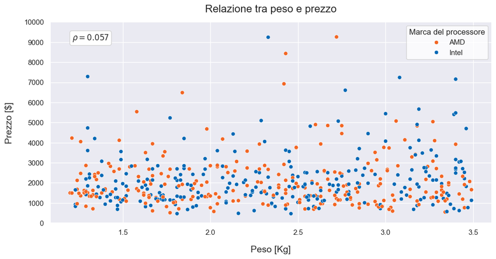

# Il prezzo varia regolarmente in base alla risoluzione schermo?

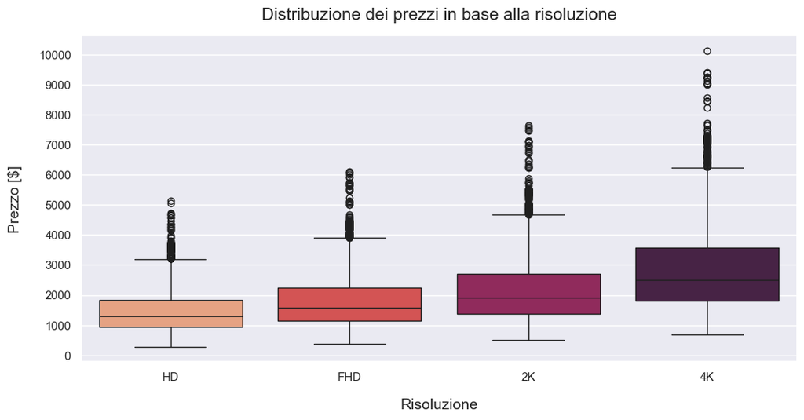

# Negli anni il divario di prezzo tra gli schermi 4K e FHD è diminuito?

[figure not shown]

## Conclusioni

- Intel ha una presenza maggiore rispetto a AMD ma il prezzo dei laptop sostanzialmente non cambia di molto.
- Le differenze di peso tra i vari brand potrebbero incidere sulla scelta di acquisto da parte del cliente.
- Non ci sono stati grossi cambiamenti tra i prezzi degli schermi **4K** e **FHD**. Tutti i tipi di schermo hanno una determinata fascia di prezzo che non cambia dal 2019 al 2021.